# NOAA Storm Data Analysis

Tim Shores

July 25, 2015

# Synopsis

In this report we aim to identify storm events with the greatest impact on human health, and the greatest impact on valuable property, across the United States from January 1995 to November 2011.

The code chunks in this report will directly import the [U.S. National Oceanic and Atmospheric Administration’s (NOAA) storm database](https://d396qusza40orc.cloudfront.net/repdata%2Fdata%2FStormData.csv.bz2), and process the data to compute results relevant to the above questions. [Storm database documentation](https://d396qusza40orc.cloudfront.net/repdata%2Fpeer2_doc%2Fpd01016005curr.pdf) and [FAQ](https://d396qusza40orc.cloudfront.net/repdata%2Fpeer2_doc%2FNCDC%20Storm%20Events-FAQ%20Page.pdf) are available.

# Data Processing

First we load software libraries and display the processing software environment.

```r
library(dplyr)      # for cleaning and exploring data
```

```r
library(ggplot2)    # for plots
options(scipen = 10) # to prevent numbers displayed with scientific notation
```

Next we load the data.

```r
datapath <-
    paste("/home/tim/datasciencecoursera/Practicing-R/Reproducible Research/PeerAssessment2/repdata_data_StormData.csv.bz2")
storm0 <- read.csv(datapath)
storm0$BGN_DATE <- as.POSIXct(storm0$BGN_DATE, format = "%m/%d/%Y %H:%M:%S")
    # This converts factor to dates, for easier filtering of rows.
```

After importing the data, we display details about the data frame, including the first few rows and columns. There are 902,297 rows and 37 columns in this dataset. The variable headers are descriptive enough, so I don’t modify them.

```r
dim(storm0)
```

```
## [1] 902297     37
```

```r
head(storm0[, 1:8])
```

```
##   STATE__   BGN_DATE BGN_TIME TIME_ZONE COUNTY COUNTYNAME STATE  EVTYPE
## 1       1 1950-04-18     0130       CST     97     MOBILE    AL TORNADO
## 2       1 1950-04-18     0145       CST      3    BALDWIN    AL TORNADO
## 3       1 1951-02-20     1600       CST     57    FAYETTE    AL TORNADO
## 4       1 1951-06-08     0900       CST     89    MADISON    AL TORNADO
## 5       1 1951-11-15     1500       CST     43    CULLMAN    AL TORNADO
## 6       1 1951-11-15     2000       CST     77 LAUDERDALE    AL TORNADO
```

Next, we prepare data for the first question, which seeks to rank storm events by harmfulness to health. The question is not limited by timeframe or location. We only need variables for types of events and health outcomes, which we interpret to mean INJURIES and FATALITIES. These will be added together as a new variable, Harm.total. Since the NOAA database includes storm data beginning in 1950, we must filter out the earlier data.

```r
storm1 <-
    storm0 %>%
    group_by(EVTYPE) %>%
    select(EVTYPE, BGN_DATE, FATALITIES, INJURIES, REMARKS, REFNUM) %>%
    mutate(Harm.total = FATALITIES + INJURIES) %>%
    filter(BGN_DATE > "1994-12-31")
```

We also check for missing values in the selected dataset, coded as NA (there are none).

```r
mean(is.na(storm1))
```

```
## [1] 0
```

We next summarise this Harm.total data, grouped by storm event type, to obtain sum, mean, and standard deviation. We extract the top five sum and mean harmful events, then combine these uniquely to produce a set of most harmful storm events. We remove events with no standard deviation, as these indicate events that only happen once – singular events should not attract the attention of managers.

```r
storm1.summary <-
    storm1 %>%
    summarise(Harm.sum = sum(Harm.total),
              Harm.mean = round(mean(Harm.total), 5),
              Harm.sd = sd(Harm.total)) %>%
    filter(Harm.sum > 0)

# this creates three separate top five harmful sum, mean, and median,
# then jams them together, removing duplicates.
top.harm.sum <- top_n(storm1.summary, 5, Harm.sum)
top.harm.mean <- top_n(storm1.summary, 5, Harm.mean)
storm1.top.harm <- unique(rbind(top.harm.sum, top.harm.mean))
storm1.top.harm <- filter(storm1.top.harm, !is.na(Harm.sd))
```

Next we prepare data for the second question, which seeks to rank storm events by economic consquences. This question is also not limited by timeframe or location. We only need variables for types of events and economic outcomes, which is coded as ‘damage’ values representing dollar amounts for property and for crops.

Both damage variables are accompanied by DMGEXP factor variables that define the value magnitude:

- K for thousands of dollars
- M for millions
- B for billions

```r
storm2 <-
    storm0 %>%
    group_by(EVTYPE) %>%
    select(EVTYPE, BGN_DATE, PROPDMG, PROPDMGEXP, CROPDMG, CROPDMGEXP, REMARKS, REFNUM) %>%
    mutate(
       PROPDMG = ifelse(PROPDMGEXP == "K",
                        PROPDMG,
                        ifelse(PROPDMG == "M",
                               PROPDMG * 1000,
                               PROPDMG * 1000000)),
       CROPDMG = ifelse(CROPDMGEXP == "K",
                        CROPDMG,
                        ifelse(CROPDMG == "M",
                               CROPDMG * 1000,
                               CROPDMG * 1000000))
       ) %>%
    mutate(Dmg.total = PROPDMG + CROPDMG) %>%
    filter(BGN_DATE > "1994-12-31")
```

We also check for missing values in the selected dataset, coded as NA (again there are none).

```r
mean(is.na(storm2))
```

```
## [1] 0
```

As with question 1 harm data, the economic damage data is summarised by storm event type groups, producing a list of the top damaging event types that happen more than once.

```r
storm2.summary <-
    storm2 %>%
    summarise(Dmg.sum = round(sum(Dmg.total), 2),
              Dmg.mean = round(mean(Dmg.total), 2),
              Dmg.sd = round(sd(Dmg.total), 2)) %>%
    filter(Dmg.sum > 0)

# this creates three separate top five damaging sum, mean, and median,
# then jams them together, removing duplicates.
top.dmg.sum <- top_n(storm2.summary, 5, Dmg.sum)
top.dmg.mean <- top_n(storm2.summary, 5, Dmg.mean)
storm2.top.dmg <- unique(rbind(top.dmg.sum, top.dmg.mean))
storm2.top.dmg <- filter(storm2.top.dmg, !is.na(Dmg.sd))
```

# Results

Across the United States, this data frame shows events that are most harmful with respect to population health.

```r
storm1.top.harm
```

```
## Source: local data frame [6 x 4]
##
##              EVTYPE Harm.sum Harm.mean   Harm.sd
## 1    EXCESSIVE HEAT     8428   5.03164 27.473038
## 2             FLOOD     7192   0.29187 11.195921
## 3         LIGHTNING     5360   0.37535  1.311868
## 4           TORNADO    23310   0.95788 13.384723
## 5         TSTM WIND     3871   0.03003  0.522294
## 6 HURRICANE/TYPHOON     1339  15.21591 90.659582
```

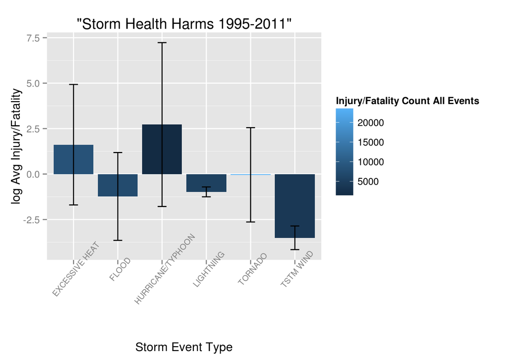

```r
harm.p <- ggplot(data = storm1.top.harm,
                 aes(x = EVTYPE,
                     y = log(Harm.mean),
                     fill = Harm.sum,
                     title = "Storm Health Harms 1995-2011"))
harm.p + geom_bar(stat = "identity") +
    xlab("Storm Event Type") +
    theme(axis.text.x = element_text(angle=50, size=8)) +
    ylab("log Avg Injury/Fatality") +
    scale_fill_continuous(name = "Injury/Fatality Count All Events") +
    geom_errorbar(aes(ymin = log(Harm.mean)-log(Harm.sd), ymax = log(Harm.mean)+log(Harm.sd)),
                  width=.2, position=position_dodge(.9))
```

Across the United States, this data frame shows events that have the greatest economic consequences.

```r
storm2.top.dmg
```

```
## Source: local data frame [7 x 4]
##
##              EVTYPE     Dmg.sum    Dmg.mean    Dmg.sd
## 1           DROUGHT 13445694002  5441397.82  38028797
## 2       FLASH FLOOD 14627973907   277712.94   4639339
## 3             FLOOD 26109076237  1059578.60  15000094
## 4              HAIL 15452687408    71562.75   3583127
## 5           TORNADO 18964901225   779326.12   9834071
## 6         HAILSTORM   241000000 80333333.33 121327381
## 7 HURRICANE/TYPHOON  4965055673 56421087.19 132197649
```

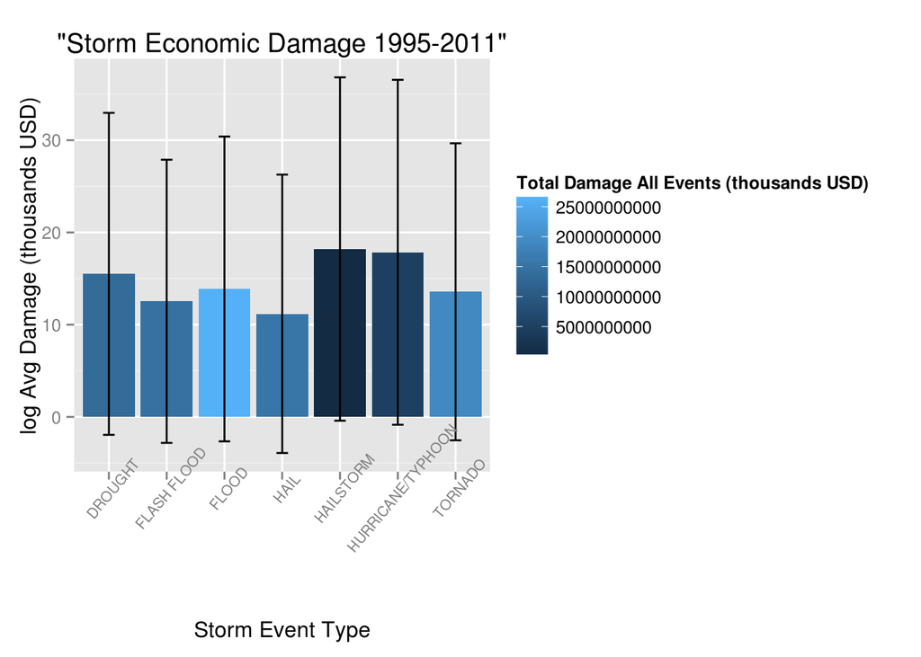

```r
dmg.p <- ggplot(data = storm2.top.dmg,
                aes(x = EVTYPE,
                    y = log(Dmg.mean),
                    fill = Dmg.sum,
                    title = "Storm Economic Damage 1995-2011"))
dmg.p + geom_bar(stat = "identity") +
    xlab("Storm Event Type") +
    theme(axis.text.x = element_text(angle=50, size=8)) +
    ylab("log Avg Damage (thousands USD)") +
    scale_fill_continuous(name = "Total Damage All Events (thousands USD)") +
    geom_errorbar(aes(ymin = log(Dmg.mean)-log(Dmg.sd), ymax = log(Dmg.mean)+log(Dmg.sd)),
                  width=.2, position=position_dodge(.9))
```